# Direct, total and separable effects, using G-formula

## Conditional pooled logistic models

- First, we run a set of conditional pooled logistic models, both as a first step to calculate the risk of prostate cancer death, and to calculate weights for death due to other causes, and weights for censoring due to loss to follow-up

```r
### Pooled logistic regression for prostate cancer death

plrFitP <-
  glm(
    prostateDeath ~ rx * (dtime + I(dtime ^ 2) + I(dtime ^ 3)) + normalAct + ageCat + hx + hgBinary ,
    data = longProstRed,
    family = binomial())

### Pooled logistic regression for death due to other causes

plrFitO <-
  glm(
    otherDeath ~ dtime + I(dtime ^ 2) + normalAct + ageCat + hx + hgBinary + rx ,
    data = longProstRed,
    family = binomial())
```

## Direct effect

- Create two expanded datasets so that hazards given A=1 can be computed for all subjects (even those with A=0), and viceversa (everyone has A = 0). In an RCT this is not necessary, could stratify models above and this step by treatment arm.
- Data set construction where A = 1

```r
treated <- baseline[rep(1:n,each=length(cutTimes)),] #One row for each interval k+1 for k=0,...,K
treated$dtime <- rep(cutTimes,n)
treated$rx <-1
```

- Data set construction where A = 0

```r
# Make analogous dataset for placebo
placebo <- baseline[rep(1:n,each=length(cutTimes)),] #One row for each time
placebo$dtime <- rep(cutTimes,n)
placebo$rx <- 0
```

- Estimate conditional discrete hazards (cause specific for each cause of death/competing event conditioned for event and hazard of competing event) for each subject in each time interval in both cloned datasets

```r
treated$hazardP <- predict(plrFitP, newdata = treated, type = 'response')
treated$hazardO <- 0
treated$s <- (1-treated$hazardP) * (1-treated$hazardO)

placebo$hazardP <- predict(plrFitP, newdata = placebo, type = 'response')
placebo$hazardO <- 0
placebo$s <- (1-placebo$hazardP) * (1-placebo$hazardO)
```

- Glimpse of “treated” data:

```r
treated %>%
  filter(patno %in% c(489)) %>% select(
    patno, dtime, rx, hazardP, hazardO, s
  ) %>% slice(1:5, 55:59) %>%  knitr::kable()
```

|  | patno | dtime | rx | hazardP | hazardO | s |
| --- | --- | --- | --- | --- | --- | --- |
| 8478 | 489 | 0 | 1 | 0.0231061 | 0 | 0.9768939 |
| 8478.1 | 489 | 1 | 1 | 0.0234620 | 0 | 0.9765380 |
| 8478.2 | 489 | 2 | 1 | 0.0238175 | 0 | 0.9761825 |
| 8478.3 | 489 | 3 | 1 | 0.0241730 | 0 | 0.9758270 |
| 8478.4 | 489 | 4 | 1 | 0.0245289 | 0 | 0.9754711 |
| 8478.54 | 489 | 54 | 1 | 0.0658483 | 0 | 0.9341517 |
| 8478.55 | 489 | 55 | 1 | 0.0681584 | 0 | 0.9318416 |
| 8478.56 | 489 | 56 | 1 | 0.0706130 | 0 | 0.9293870 |
| 8478.57 | 489 | 57 | 1 | 0.0732226 | 0 | 0.9267774 |
| 8478.58 | 489 | 58 | 1 | 0.0759986 | 0 | 0.9240014 |

- Glimpse of “placebo” data:

```r
placebo %>%
  filter(patno %in% c(489)) %>% select(
    patno, dtime, rx, hazardP, hazardO, s
  ) %>% slice(1:5, 55:59) %>%  knitr::kable()
```

|  | patno | dtime | rx | hazardP | hazardO | s |
| --- | --- | --- | --- | --- | --- | --- |
| 8478 | 489 | 0 | 0 | 0.0458879 | 0 | 0.9541121 |
| 8478.1 | 489 | 1 | 0 | 0.0431460 | 0 | 0.9568540 |
| 8478.2 | 489 | 2 | 0 | 0.0409669 | 0 | 0.9590331 |
| 8478.3 | 489 | 3 | 0 | 0.0392643 | 0 | 0.9607357 |
| 8478.4 | 489 | 4 | 0 | 0.0379704 | 0 | 0.9620296 |
| 8478.54 | 489 | 54 | 0 | 0.0142297 | 0 | 0.9857703 |
| 8478.55 | 489 | 55 | 0 | 0.0113442 | 0 | 0.9886558 |
| 8478.56 | 489 | 56 | 0 | 0.0088875 | 0 | 0.9911125 |
| 8478.57 | 489 | 57 | 0 | 0.0068390 | 0 | 0.9931610 |
| 8478.58 | 489 | 58 | 0 | 0.0051668 | 0 | 0.9948332 |

We will implement the following estimator, wrapped as the function `calculateCumInc` from the `utility_functions` script available in this repository.

```r
calculateCumInc <-
  function(inputData,
           timepts = cutTimes,
           competing = FALSE) {
    cumulativeIncidence <-
      matrix(NA, ncol = length(unique(inputData$patno)), nrow = length(cutTimes))
    # Insert the event probabilities at the first time interval:
    cumulativeIncidence[1,] <-
      inputData[inputData$dtime == 0,]$hazardP * inputData[inputData$dtime ==
                                                             0,]$hazardO
    # Create a matrix compatible with 'cumulativeIncidence' with survival probabilities at each time
    survivalProb <-
      t(aggregate(s ~ patno, data = inputData, FUN = cumprod)$s) #split the long data into subsets per subject
    for (i in 2:length(cutTimes)) {
      subInputDataP <-
        inputData[inputData$dtime == (i - 1),]$hazardP #OBS: dtime starts at 0
      subInputDataO <-
        (1 - inputData[inputData$dtime == (i - 1),]$hazardO) #OBS: dtime starts at 0
      if (!competing)
        cumulativeIncidence[i,] <-
        subInputDataO *  subInputDataP * survivalProb[(i - 1),] # OBS: survivalProb entry i is time point i-1
      else
        cumulativeIncidence[i,] <-
        (1 - subInputDataO) * survivalProb[(i - 1),]
    }
    meanCumulativeIncidence <-
      rowMeans(apply(cumulativeIncidence, MARGIN = 2, cumsum)) #rowMeans(cumulativeIncidence)
    return(meanCumulativeIncidence)
  }
```

```r
cumIncTreated <- calculateCumInc(treated)#a=1
cumIncPlacebo <- calculateCumInc(placebo)#a=0

cumIncTreated_de_60 <- cumIncTreated[length(cutTimes)]

cumIncPlacebo_de_60 <- cumIncPlacebo[length(cutTimes)]

de_rr <- cumIncTreated_de_60 / cumIncPlacebo_de_60

de_rd <- cumIncTreated_de_60 - cumIncPlacebo_de_60

results_de <- data.frame(cumIncTreated_de_60, cumIncPlacebo_de_60, de_rr, de_rd)

knitr::kable(round(results_de, 2))
```

| cumIncTreated_de_60 | cumIncPlacebo_de_60 | de_rr | de_rd |
| --- | --- | --- | --- |
| 0.34 | 0.39 | 0.88 | -0.05 |

## Total effect

- We are going to use the same code as in the previous section, except that in this case instead of fixing the hazard of other causes to death as 0, we are going to calculate hazards for this outcome using predicted values from the `plrfit0` model and recalculate the survival probability, given death

```r
treated$hazardO <- predict(plrFitO, newdata = treated, type = 'response')

treated$s <- (1-treated$hazardP) * (1-treated$hazardO)

placebo$hazardO <- predict(plrFitO, newdata = placebo, type = 'response')

placebo$s <- (1-placebo$hazardP) * (1-placebo$hazardO)
```

- Glimpse of “treated” data:

```r
treated %>%
  filter(patno %in% c(489)) %>% select(
    patno, dtime, rx, hazardP, hazardO, s
  ) %>% slice(1:5, 55:59) %>%  knitr::kable()
```

|  | patno | dtime | rx | hazardP | hazardO | s |
| --- | --- | --- | --- | --- | --- | --- |
| 8478 | 489 | 0 | 1 | 0.0231061 | 0.0759711 | 0.9026781 |
| 8478.1 | 489 | 1 | 1 | 0.0234620 | 0.0747473 | 0.9035444 |
| 8478.2 | 489 | 2 | 1 | 0.0238175 | 0.0735928 | 0.9043425 |
| 8478.3 | 489 | 3 | 1 | 0.0241730 | 0.0725053 | 0.9050744 |
| 8478.4 | 489 | 4 | 1 | 0.0245289 | 0.0714825 | 0.9057420 |
| 8478.54 | 489 | 54 | 1 | 0.0658483 | 0.0853839 | 0.8543902 |
| 8478.55 | 489 | 55 | 1 | 0.0681584 | 0.0871989 | 0.8505860 |
| 8478.56 | 489 | 56 | 1 | 0.0706130 | 0.0891097 | 0.8465696 |
| 8478.57 | 489 | 57 | 1 | 0.0732226 | 0.0911205 | 0.8423290 |
| 8478.58 | 489 | 58 | 1 | 0.0759986 | 0.0932355 | 0.8378517 |

- Glimpse of “placebo” data:

```r
placebo %>%
  filter(patno %in% c(489)) %>% select(
    patno, dtime, rx, hazardP, hazardO, s
  ) %>% slice(1:5, 55:59) %>%  knitr::kable()
```

|  | patno | dtime | rx | hazardP | hazardO | s |
| --- | --- | --- | --- | --- | --- | --- |
| 8478 | 489 | 0 | 0 | 0.0458879 | 0.0614893 | 0.8954444 |
| 8478.1 | 489 | 1 | 0 | 0.0431460 | 0.0604835 | 0.8989802 |
| 8478.2 | 489 | 2 | 0 | 0.0409669 | 0.0595351 | 0.9019369 |
| 8478.3 | 489 | 3 | 0 | 0.0392643 | 0.0586422 | 0.9043961 |
| 8478.4 | 489 | 4 | 0 | 0.0379704 | 0.0578028 | 0.9064217 |
| 8478.54 | 489 | 54 | 0 | 0.0142297 | 0.0692422 | 0.9175134 |
| 8478.55 | 489 | 55 | 0 | 0.0113442 | 0.0707406 | 0.9187176 |
| 8478.56 | 489 | 56 | 0 | 0.0088875 | 0.0723194 | 0.9194359 |
| 8478.57 | 489 | 57 | 0 | 0.0068390 | 0.0739820 | 0.9196849 |
| 8478.58 | 489 | 58 | 0 | 0.0051668 | 0.0757324 | 0.9194921 |

- Calculate risks and corresponding treatment effects (RR/RD) by end of follow-up using parametric g-formula

```r
cumIncTreated_te <- calculateCumInc(treated)#a=1
cumIncPlacebo_te <- calculateCumInc(placebo)#a=0

cumIncTreated_te_60 <- cumIncTreated_te[length(cutTimes)]

cumIncPlacebo_te_60 <- cumIncPlacebo_te[length(cutTimes)]

te_rr <- cumIncTreated_te_60 / cumIncPlacebo_te_60

te_rd <- cumIncTreated_te_60 - cumIncPlacebo_te_60

results_te <- data.frame(cumIncTreated_te_60, cumIncPlacebo_te_60, te_rr, te_rd)

knitr::kable(round(results_te, 2))
```

| cumIncTreated_te_60 | cumIncPlacebo_te_60 | te_rr | te_rd |
| --- | --- | --- | --- |
| 0.21 | 0.28 | 0.74 | -0.07 |

## Total effect of death on other causes

```r
# parametric g-formula estimate of the risk of the competing event itself
cumIncTreated_te_comp <- calculateCumInc(treated, competing = TRUE)#a=1

cumIncPlacebo_te_comp <- calculateCumInc(placebo, competing = TRUE)#a=0

cumIncTreated_te_comp_60 <- cumIncTreated_te_comp[length(cutTimes)]

cumIncPlacebo_te_comp_60 <- cumIncPlacebo_te_comp[length(cutTimes)]

te_comp_rr <- cumIncTreated_te_comp_60 / cumIncPlacebo_te_comp_60

te_comp_rd <- cumIncTreated_te_comp_60 - cumIncPlacebo_te_comp_60

results_te_comp <- data.frame(cumIncTreated_te_comp_60, cumIncPlacebo_te_comp_60, te_comp_rr, te_comp_rd)

knitr::kable(round(results_te_comp, 2))
```

| cumIncTreated_te_comp_60 | cumIncPlacebo_te_comp_60 | te_comp_rr | te_comp_rd |
| --- | --- | --- | --- |
| 0.51 | 0.41 | 1.23 | 0.09 |

## Separable effects

Following equation (9) from [Stensrud et al. Journal of the American Statistical Association. 2020](https://www.tandfonline.com/doi/full/10.1080/01621459.2020.1765783)

To this matter, we will use the long format data set prepared before: `longProstRed`.

- Make one extra copy of the exposure `rx`, named `Orx`, to be used in the hazard of death due to other causes.

```r
longProstRed$Orx <- longProstRed$rx
```

- Fit conditional pooled logistic regression models

```r
plrFitP <-
    glm(
      prostateDeath ~ rx*(dtime + I(dtime ^ 2)+ I(dtime ^ 3)) + normalAct + ageCat + hx + hgBinary,
      data = longProstRed,
      family = binomial()
    )

plrFitO <-
  glm(
    otherDeath ~ Orx * (dtime + I(dtime ^ 2) + I(dtime ^ 3)) + normalAct + ageCat + hx + hgBinary,
    data = longProstRed,
    family = binomial()
  )
```

Create three copies of the data:

- Data set construction where Ay and Ad = 1

```r
treated <-
    baseline[rep(1:n, each = length(cutTimes)), ] #One row for each time

treated$dtime <- rep(cutTimes, n)

treated$rx <- 1

treated$Orx <- 1
```

```r
placebo <-
    baseline[rep(1:n, each = length(cutTimes)), ] #One row for each time

placebo$dtime <- rep(cutTimes, n)

placebo$rx <- 0

placebo$Orx <- 0
```

- Dataset construction where Ay = 1, Ad = 0

```r
treatAy <-
    baseline[rep(1:n, each = length(cutTimes)), ]

treatAy$dtime <- rep(cutTimes, n)

treatAy$rx <- 1

treatAy$Orx <- 0
```

- Calculate hazards for each time interval in the three cloned data sets

```r
## For Ay = 1 and Ad = 1

treated$hazardP <-
    predict(plrFitP, newdata = treated, type = 'response')

treated$hazardO <-
    predict(plrFitO, newdata = treated, type = 'response')

treated$s <- (1 - treated$hazardP) * (1 - treated$hazardO)

## For Ay = 0, Ad = 0

placebo$hazardP <-
    predict(plrFitP, newdata = placebo, type = 'response')

placebo$hazardO <-
    predict(plrFitO, newdata = placebo, type = 'response')

placebo$s <- (1 - placebo$hazardP) * (1 - placebo$hazardO)

## For Ay = 1, Ad = 0

treatAy$hazardP <-
    predict(plrFitP, newdata = treatAy, type = 'response')

treatAy$hazardO <-
    predict(plrFitO, newdata = treatAy, type = 'response')

treatAy$s <- (1 - treatAy$hazardP) * (1 - treatAy$hazardO)
```

- Glimpse of “treated” data:

```r
treated %>%
  filter(patno %in% c(489)) %>% select(
    patno, dtime, rx, Orx, hazardP, hazardO, s
  ) %>% slice(1:5, 55:59) %>%  knitr::kable()
```

|  | patno | dtime | rx | Orx | hazardP | hazardO | s |
| --- | --- | --- | --- | --- | --- | --- | --- |
| 8478 | 489 | 0 | 1 | 1 | 0.0231061 | 0.1215098 | 0.8581917 |
| 8478.1 | 489 | 1 | 1 | 1 | 0.0234620 | 0.1070610 | 0.8719889 |
| 8478.2 | 489 | 2 | 1 | 1 | 0.0238175 | 0.0951232 | 0.8833249 |
| 8478.3 | 489 | 3 | 1 | 1 | 0.0241730 | 0.0852474 | 0.8926403 |
| 8478.4 | 489 | 4 | 1 | 1 | 0.0245289 | 0.0770658 | 0.9002956 |
| 8478.54 | 489 | 54 | 1 | 1 | 0.0658483 | 0.0763298 | 0.8628481 |
| 8478.55 | 489 | 55 | 1 | 1 | 0.0681584 | 0.0726713 | 0.8641235 |
| 8478.56 | 489 | 56 | 1 | 1 | 0.0706130 | 0.0686332 | 0.8656002 |
| 8478.57 | 489 | 57 | 1 | 1 | 0.0732226 | 0.0642719 | 0.8672116 |
| 8478.58 | 489 | 58 | 1 | 1 | 0.0759986 | 0.0596529 | 0.8688820 |

- Glimpse of “placebo” data:

```r
placebo %>%
  filter(patno %in% c(489)) %>% select(
    patno, dtime, rx, Orx, hazardP, hazardO, s
  ) %>% slice(1:5, 55:59) %>%  knitr::kable()
```

|  | patno | dtime | rx | Orx | hazardP | hazardO | s |
| --- | --- | --- | --- | --- | --- | --- | --- |
| 8478 | 489 | 0 | 0 | 0 | 0.0458879 | 0.0509117 | 0.9055366 |
| 8478.1 | 489 | 1 | 0 | 0 | 0.0431460 | 0.0501587 | 0.9088594 |
| 8478.2 | 489 | 2 | 0 | 0 | 0.0409669 | 0.0495393 | 0.9115233 |
| 8478.3 | 489 | 3 | 0 | 0 | 0.0392643 | 0.0490433 | 0.9136181 |
| 8478.4 | 489 | 4 | 0 | 0 | 0.0379704 | 0.0486621 | 0.9152153 |
| 8478.54 | 489 | 54 | 0 | 0 | 0.0142297 | 0.0488282 | 0.9376369 |
| 8478.55 | 489 | 55 | 0 | 0 | 0.0113442 | 0.0468247 | 0.9423623 |
| 8478.56 | 489 | 56 | 0 | 0 | 0.0088875 | 0.0447376 | 0.9467726 |
| 8478.57 | 489 | 57 | 0 | 0 | 0.0068390 | 0.0425801 | 0.9508721 |
| 8478.58 | 489 | 58 | 0 | 0 | 0.0051668 | 0.0403663 | 0.9546755 |

- Glimpse of “treatAy” data:

```r
treatAy %>%
  filter(patno %in% c(489)) %>% select(
    patno, dtime, rx, Orx, hazardP, hazardO, s
  ) %>% slice(1:5, 55:59) %>%  knitr::kable()
```

|  | patno | dtime | rx | Orx | hazardP | hazardO | s |
| --- | --- | --- | --- | --- | --- | --- | --- |
| 8478 | 489 | 0 | 1 | 0 | 0.0231061 | 0.0509117 | 0.9271586 |
| 8478.1 | 489 | 1 | 1 | 0 | 0.0234620 | 0.0501587 | 0.9275561 |
| 8478.2 | 489 | 2 | 1 | 0 | 0.0238175 | 0.0495393 | 0.9278231 |
| 8478.3 | 489 | 3 | 1 | 0 | 0.0241730 | 0.0490433 | 0.9279692 |
| 8478.4 | 489 | 4 | 1 | 0 | 0.0245289 | 0.0486621 | 0.9280027 |
| 8478.54 | 489 | 54 | 1 | 0 | 0.0658483 | 0.0488282 | 0.8885387 |
| 8478.55 | 489 | 55 | 1 | 0 | 0.0681584 | 0.0468247 | 0.8882084 |
| 8478.56 | 489 | 56 | 1 | 0 | 0.0706130 | 0.0447376 | 0.8878085 |
| 8478.57 | 489 | 57 | 1 | 0 | 0.0732226 | 0.0425801 | 0.8873151 |
| 8478.58 | 489 | 58 | 1 | 0 | 0.0759986 | 0.0403663 | 0.8867029 |

- Calculate cumulative incidence

```r
cumIncTreated <- calculateCumInc(treated)
cumIncTreatAy <- calculateCumInc(treatAy)
cumIncPlacebo <- calculateCumInc(placebo)

estimatesFullData <-
  data.frame(cumIncTreated, cumIncTreatAy, cumIncPlacebo)

knitr::kable(round(estimatesFullData[36,], 2))
```

|  | cumIncTreated | cumIncTreatAy | cumIncPlacebo |
| --- | --- | --- | --- |
| 36 | 0.13 | 0.14 | 0.21 |

- Cumulative incidence curves

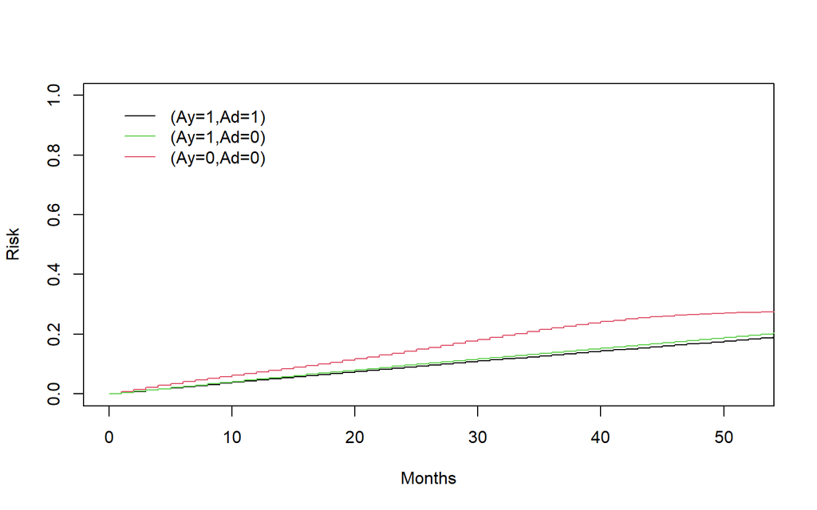

```r
plot(cutTimes, cumIncTreated, type = "s",
     ylim = c(0, 1), ylab = "Risk",
     xlab = "Months",
     lty = 1, lwd = 1, xlim = c(0, 52))

lines(cutTimes, cumIncPlacebo, type = "s",
      col = 2, ylim = c(0, 1), lwd = 1)

lines(cutTimes, cumIncTreatAy, type = "s",
      col = 3, ylim = c(0, 1), lwd = 1)

legend(x = 0, y = 1,
       c("(Ay=1,Ad=1)", "(Ay=1,Ad=0)", "(Ay=0,Ad=0)"),
       bty = "n", col = c(1, 3, 2),
       lty = c(1, 1, 1), cex = 1, pt.cex = 1, lwd = 1)
```

### [Go to: Data cleaning and setup here](https://palolili23.github.io/SER_competing_events_workshop/R/index.html)

### [Go to: Direct, total and separable effects, using IPW](https://palolili23.github.io/SER_competing_events_workshop/R/ipw.html)

### [Go to github repository](https://github.com/palolili23/SER_competing_events_workshop)

# References

- Young JG, Stensrud MJ, Tchetgen Tchetgen EJ, Hernán MA. A causal framework for classical statistical estimands in failure time settings with competing events. Statistics in Medicine 2020. [Paper link](https://onlinelibrary.wiley.com/doi/abs/10.1002/sim.8471) [Code](https://github.com/CausalInference/CompetingEvents_Young_SIM_2020)
- Stensrud MJ, Young JG, Didelez V, Robins JM, Hernán MA. Separable Effects for Causal Inference in the Presence of Competing Events. Journal of the American Statistical Association 2022. [Paper link](https://www.tandfonline.com/doi/full/10.1080/01621459.2020.1765783)
- Rojas-Saunero LP, Young JG, Didelez V, Ikram MA, Swanson SA. Considering questions before methods in dementia research with competing events and causal goals. American Journal of Epidemiology. 2023. [Paper link](https://academic.oup.com/aje/advance-article/doi/10.1093/aje/kwad090/7120022) [Code](https://github.com/palolili23/competing_risks_dementia)